# 6 Reasons Why You Should Start Using R

June 18th, 2015

## What is R?

## What is R?

### According to [Wikipedia](http://en.wikipedia.org/wiki/R_%28programming_language%29):

> A **programming language** and software environment for **statistical computing** and graphics.

> It is widely used among statisticians and data miners for **developing statistical software and data analysis**.

> Its popularity has **increased substantially** in recent years.

## What is R?

### According to [R Foundation](http://www.r-project.org/):

> An **integrated suite** of software facilities for **data manipulation**, **calculation** and **graphical display**.

## What to expect from this presentation?

## What to expect from this presentation?

- R for beginners
  - Features
- Examples
  - Code
  - Tools
  - Packages

## Data sets

## Data sets

1. **Activities in a store**

## Data sets

Activities in a store

| colour.name | colour.code | productid | skuid |
| --- | --- | --- | --- |
| NEGRO | #2c2b31 | 6103880034 | 8433815102928 |
| AVELLANA | #E1D8D1 | 6103870033 | 8433815103376 |
| AVELLANA | #E1D8D1 | 1813659542 | 8433815080622 |
| VERDE MANZANA | #65db80 | 1333989684 | 8433815097019 |
| MARENGO | #595f6b | 1783619976 | 8433815103338 |
| CARMIN | #fe6557 | 1333989684 | 8433815097064 |

## Data sets

1. Activities in a store
2. **Internet users around the world**

## Data sets

Internet users around the world

| Country.Name.x | Indicator.Name | Indicator.Code | X1960 |
| --- | --- | --- | --- |
| Aruba | Internet users (per 100 people) | IT.NET.USER.P2 | NA |
| Afghanistan | Internet users (per 100 people) | IT.NET.USER.P2 | NA |
| Angola | Internet users (per 100 people) | IT.NET.USER.P2 | NA |
| Albania | Internet users (per 100 people) | IT.NET.USER.P2 | NA |

*… it continues until 2013*

## Data sets

1. Activities in a store
2. Internet users around the world
3. **Internet services around the world**

## Data sets

Internet services around the world

| Region | Country | Technology | Downstream.bandwidth |
| --- | --- | --- | --- |
| Asia | Afghanistan | ADSL | 128 |
| Asia | Afghanistan | ADSL | 256 |
| Asia | Afghanistan | ADSL | 512 |
| Asia | Afghanistan | ADSL | 1024 |

## Data sets

1. Activities in a store
2. Internet users around the world
3. Internet services around the world
4. **Activities in an online course**

## Data sets

### 4. Activities in an online course

```
{
    "username": "---",
    "event_type": "load_video",
    "ip": "---",
    "agent": "Mozilla/5.0 (Windows NT 6.0) AppleWebKit/537.36 (KHTML, like Gecko) Chrome/37.0.2062.124 Safari/537.36",
    "host": "www.ucatx.cat",
    "session": "f689d6cd57bb0f68a1a8759fd251088d",
    "event": "{\"id\":\"i4x-UPF-C01-video-7ebca4d2e7164f6d944875cede5aa753\",\"code\":\"Eysn011TDjg\"}",
    "event_source": "browser",
    "context": {
        "username": "---",
        "user_id": 149,
        "ip": "---",
        "org_id": "UPF",
        "agent": "Mozilla/5.0 (Windows NT 6.0) AppleWebKit/537.36 (KHTML, like Gecko) Chrome/37.0.2062.124 Safari/537.36",
        "host": "www.ucatx.cat",
        "session": "f689d6cd57bb0f68a1a8759fd251088d",
        "course_id": "UPF/C01/2014",
        "path": "/event"
    },
    "time": "2014-09-29T17:19:25.295450+00:00",
    "page": "---"
}
```

## Data sets

1. Activities in a store
2. Internet users around the world
3. Internet services around the world
4. Activities in an online course
5. **Movies**

## Data sets

Movies

| movie | title | Comedy | Drama |
| --- | --- | --- | --- |
| 1 | Toy Story (1995) | 1 | 0 |
| 10 | Richard III (1995) | 0 | 1 |
| 44 | Dolores Claiborne (1994) | 0 | 1 |
| 371 | Bridges of Madison County, The (1995) | 0 | 1 |
| 558 | Heavenly Creatures (1994) | 0 | 1 |
| 1133 | Escape to Witch Mountain (1975) | 0 | 0 |

*18 different genders*

## Data sets

Users' ratings

| user | movie | rating |
| --- | --- | --- |
| 1 | 1 | 5 |
| 1 | 13 | 5 |
| 3 | 347 | 5 |
| 5 | 135 | 4 |
| 5 | 446 | 4 |
| 6 | 7 | 2 |

## 6 Reasons Why You Should Start Using R

## Reason #1 - Community

## Reason #1 - Community

- Open source
- Free
- Huge community
- Online resources
  - Courses
  - Forums

[figure not shown]

[figure not shown]

## Reason #2 - The IDE

## Reason #2 - The IDE

### Pure R:

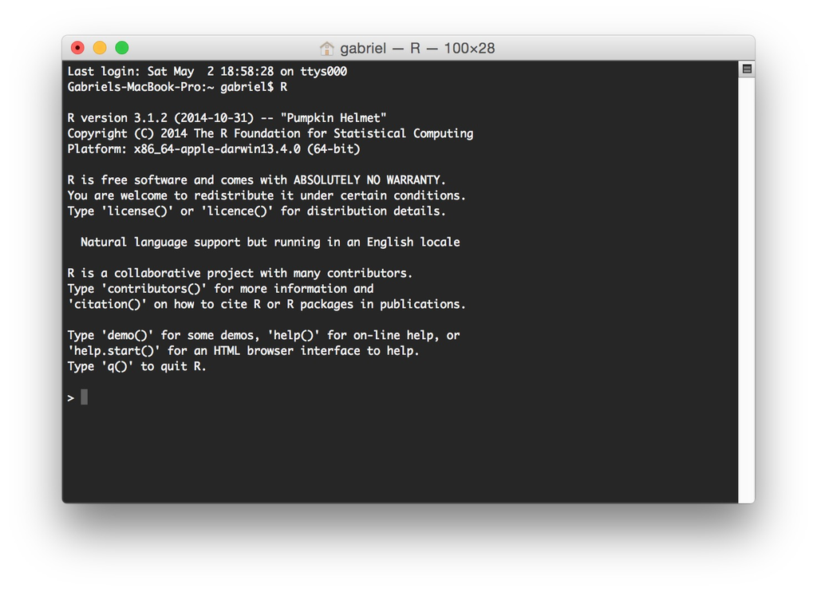

## Reason #2 - The IDE

### RStudio:

[figure not shown]

## Reason #3 - Data Manipulation

## Reason #3 - Data Manipulation

### Which product is the most wanted?

## Reason #3 - Data Manipulation

### Which product is the most wanted?

|  | colour.name | colour.code | productid | skuid |
| --- | --- | --- | --- | --- |
| **57** | NEGRO | #2c2b31 | 6351140127 | 635114012799 |
| **58** | NEGRO | #2c2b31 | 6351120125 | 635112012599 |
| **59** | GRANATE | #FF00FF | 6430610162 | 643061016269 |
| **60** | PERLA | #BCBBC0 | 1825939990 | 8433815103871 |
| **61** | PERLA | #BCBBC0 | 1825939990 | 8433815123107 |
| **62** | NEGRO | #2c2b31 | 6103920029 | 8433815103444 |

## Reason #3 - Data Manipulation

### Which product is the most wanted?

#### **Tapply**

## Reason #3 - Data Manipulation

### Which product is the most wanted?

#### **Tapply**

```r
# the number of tries per product
tries <- tapply(ds1$skuid, # list of items

                # categories
                ds1$productid,

                #function to apply
                length)
```

## Reason #3 - Data Manipulation

### Which product is the most wanted?

#### **Tapply**

```r
# the number of tries per product
tries <- tapply(ds1$skuid, # list of items

                # categories
                ds1$productid,

                #function to apply
                length)
```

```r
# the product with more tries
tries[tries == max(tries)]
```

```
## 5860769906
##         35
```

## Reason #3 - Data Manipulation

### Which combination "Product + Color"?

```r
# number of tries per product and color
tries <- tapply(ds1$skuid, # list of items

                # categories
                ds1[, c("productid", "colour.code")],

                # function to apply
                length)
```

## Reason #3 - Data Manipulation

### Which combination "Product + Color"?

```r
# number of tries per product and color
tries <- tapply(ds1$skuid, # list of items

                # categories
                ds1[, c("productid", "colour.code")],

                # function to apply
                length)

# the product with more tries
ind <- which(tries == max(tries, na.rm = TRUE), arr.ind=TRUE)
```

## Reason #3 - Data Manipulation

Top Products and Colors

| item | color |
| --- | --- |
| 5256939958 | #FF00FF |
| 5860719909 | #FF00FF |
| 5860769906 | #FF00FF |

## Reason #3 - Data Manipulation

Top Products and Colors

| item | color |
| --- | --- |
| 5256939958 | #FF00FF |
| 5860719909 | #FF00FF |
| 5860769906 | #FF00FF |

### Which color?

## Reason #3 - Data Manipulation

Data

| Country.Name | Indicator.Name | X2013 |
| --- | --- | --- |
| Cote d'Ivoire | Internet users (per 100 people) | 2.6 |
| Cameroon | Internet users (per 100 people) | 6.4 |

Metadata

| Country.Name | Region | IncomeGroup |
| --- | --- | --- |
| Côte d'Ivoire | Sub-Saharan Africa | Lower middle income |
| Cameroon | Sub-Saharan Africa | Lower middle income |

## Reason #3 - Data Manipulation

### What was the European country with the greatest % of users in 2013?

## Reason #3 - Data Manipulation

### What was the European country with the greatest % of users in 2013?

#### **Merge**

```r
ds2 <- merge(ds2.p1, ds2.p2, by = "Country.Code")
```

## Reason #3 - Data Manipulation

### What was the European country with the greatest % of users in 2013?

#### **Merge**

```r
ds2 <- merge(ds2.p1, ds2.p2, by = "Country.Code")
```

### **Subset**

```r
european <- subset(ds2, Region == "Europe & Central Asia")
```

## Reason #3 - Data Manipulation

### What was the European country with the greatest % of users in 2013?

#### **Merge**

```r
ds2 <- merge(ds2.p1, ds2.p2, by = "Country.Code")
```

### **Subset**

```r
european <- subset(ds2, Region == "Europe & Central Asia")
```

```r
order.ind <- order(as.numeric(european$X2013), decreasing = T)
```

```r
european[order.ind, ]
```

## Reason #3 - Data Manipulation

|  | Country.Code | Country.Name.x | X2013 |
| --- | --- | --- | --- |
| **105** | ISL | Iceland | 96.55 |
| **168** | NOR | Norway | 95.05 |
| **212** | SWE | Sweden | 94.78 |
| **57** | DNK | Denmark | 94.63 |
| **5** | AND | Andorra | 94 |
| **166** | NLD | Netherlands | 93.96 |
| **128** | LIE | Liechtenstein | 93.8 |
| **134** | LUX | Luxembourg | 93.78 |
| **73** | FIN | Finland | 91.51 |

## Reason #4 - Data Visualization

## Reason #4 - Data Visualization

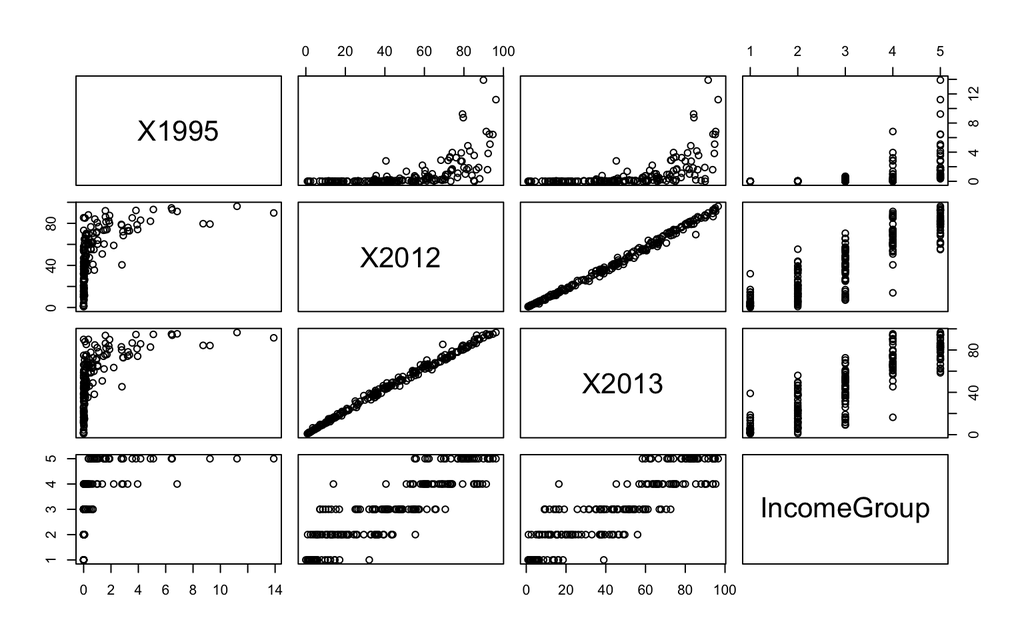

```r
pairs(ds2.obs)
```

## Reason #4 - Data Visualization

Internet services around the world

| Region | Country | Technology | Downstream.bandwidth |
| --- | --- | --- | --- |
| Asia | Uzbekistan | ADSL | 1024 |
| Oceania | Australia | FTTH | 12 |
| Oceania | Australia | ADSL | NA |
| Asia | China | FTTH | 10 |
| Asia | Jordan | ADSL | 24 |
| Asia | Bangladesh | ADSL | 64 |
| Africa | Benin | ADSL | 512 |
| South America | Brazil | ADSL | 1 |

## Reason #4 - Data Visualization

### How is the internet service in Spain?

```r
pairs(subset(ds3, Technology != "" &
                  Date.tariff.recorded == "2012Q3" &
                  Country.Name.x == "Spain")[cols])
```

## Reason #4 - Data Visualization

### How is the internet service in Spain?

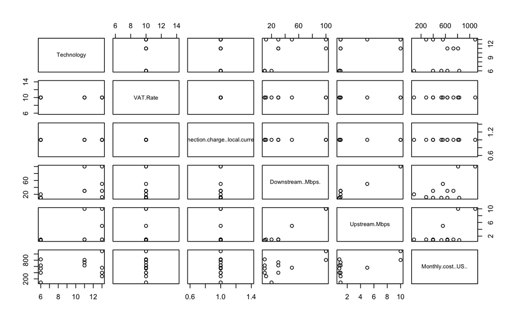

## Reason #4 - Data Visualization

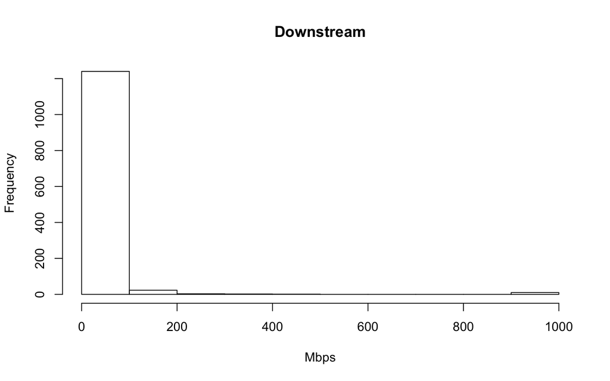

```r
hist(ds3$Downstream..Mbps., xlab = "Mbps", main = "Downstream")
```

## Reason #4 - Data Visualization

### 4. Activities in an online course

```
{
    "username": "---",
    "event_type": "load_video",
    "ip": "---",
    "agent": "Mozilla/5.0 (Windows NT 6.0) AppleWebKit/537.36 (KHTML, like Gecko) Chrome/37.0.2062.124 Safari/537.36",
    "host": "www.ucatx.cat",
    "session": "f689d6cd57bb0f68a1a8759fd251088d",
    "event": "{\"id\":\"i4x-UPF-C01-video-7ebca4d2e7164f6d944875cede5aa753\",\"code\":\"Eysn011TDjg\"}",
    "event_source": "browser",
    "context": {
        "username": "---",
        "user_id": 149,
        "ip": "---",
        "org_id": "UPF",
        "agent": "Mozilla/5.0 (Windows NT 6.0) AppleWebKit/537.36 (KHTML, like Gecko) Chrome/37.0.2062.124 Safari/537.36",
        "host": "www.ucatx.cat",
        "session": "f689d6cd57bb0f68a1a8759fd251088d",
        "course_id": "UPF/C01/2014",
        "path": "/event"
    },
    "time": "2014-09-29T17:19:25.295450+00:00",
    "page": "---"
}
```

## Reason #4 - Data Visualization

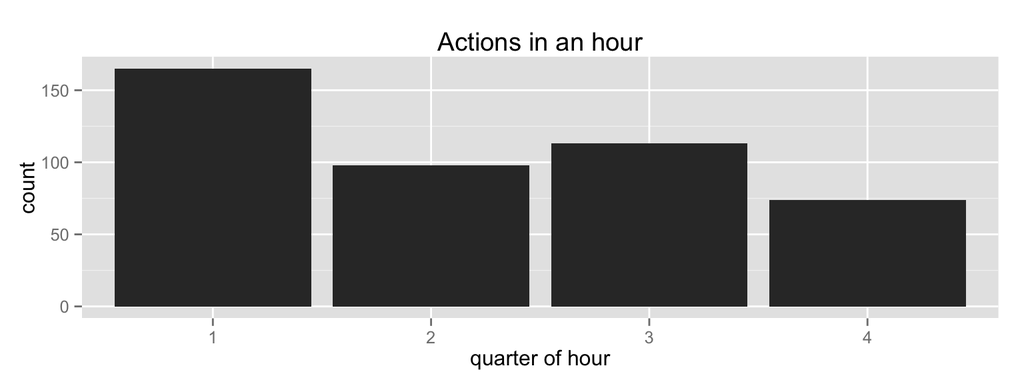

```r
qplot(data = subset(ds4,
                event_source == "browser" &                     # events from browser
                !is.na(time)),                                  # with information about the time
      x = as.character(floor(minute(time) / 15)+1),             # split the hour
      xlab = "quarter of hour", main = "Actions in an hour")    # labels
```

## Reason #4 - Data Visualization

```r
qplot(data = subset(ds4,
                event_source == "browser" &                     # events from browser
                !is.na(time)),                                  # with information about the time
      x = as.character(floor(minute(time) / 15) + 1),           # split the hour
      xlab = "quarter of hour", main = "Actions per user",      # labels
      facets = username ~ .)                                    # split based on username
```

## Reason #4 - Data Visualization

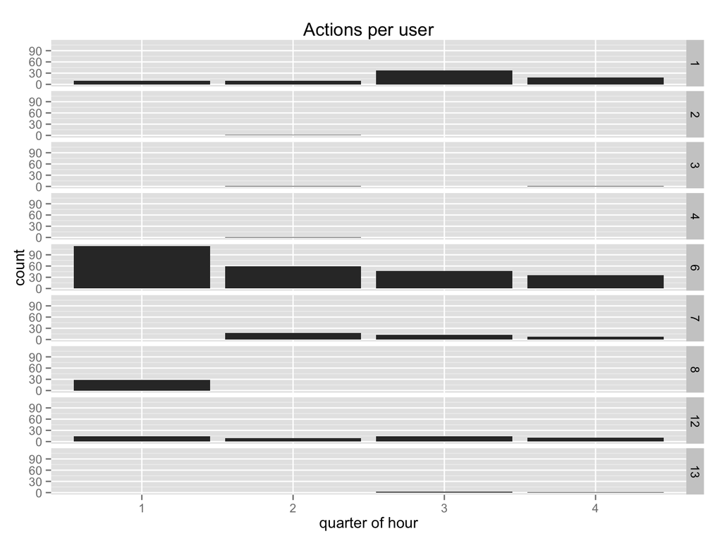

## Reason #4 - Data Visualization

```r
qplot(data = subset(ds4,
                event_source == "browser" &                     # events from browser
                !is.na(time) &                                  # with information about the time
                username == "6"),                               # only user "6""
      x = as.character(floor(minute(time) / 15) + 1),           # split the hour
      xlab = "quarter of hour", main = "Actions of user #6",    # labels
      fill = event_type)                                        # split based on event
```

## Reason #4 - Data Visualization

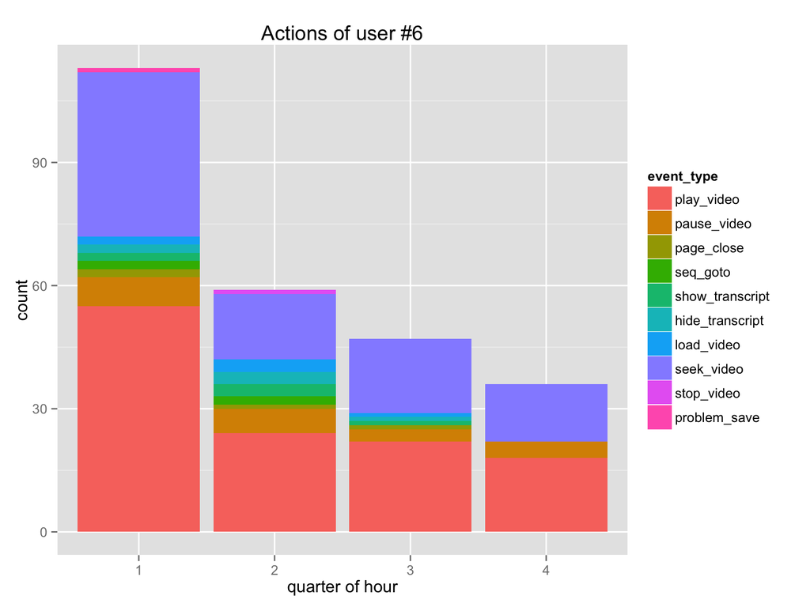

## Reason #5 - Predictions

## Reason #5 - Predictions

Users' ratings

| user | title | rating |
| --- | --- | --- |
| 1 | Toy Story (1995) | 5 |
| 6 | Twelve Monkeys (1995) | 2 |
| 1 | Mighty Aphrodite (1995) | 5 |
| 5 | 2001: A Space Odyssey (1968) | 4 |
| 3 | Wag the Dog (1997) | 5 |
| 5 | Burnt Offerings (1976) | 4 |

## Reason #5 - Predictions

### Can we recommend movies to an user based on the ratings?

## Reason #5 - Predictions

### Can we recommend movies to an user based on the ratings?

#### Using [Neural Networks](https://en.wikipedia.org/wiki/Artificial_neural_network):

```r
ds6.model.nnetwork <- train(rating ~ user + movie, data = ds6,
                   # method used
                   method = "nnet",
                   # pre processing
                   preProc = c("center", "scale"),
                   # do not show details during the training
                   trace = FALSE)
# test model
ds6.pred.nnetwork <- predict(ds6.model.nnetwork, ds6.test)
# check accuracy
postResample(ds6.pred.nnetwork, ds6.test$rating)
```

## Reason #5 - Predictions

### Can we recommend movies to an user based on the ratings?

#### Using [Neural Networks](https://en.wikipedia.org/wiki/Artificial_neural_network):

```r
ds6.model.nnetwork <- train(rating ~ user + movie, data = ds6,
                   # method used
                   method = "nnet",
                   # pre processing
                   preProc = c("center", "scale"),
                   # do not show details during the training
                   trace = FALSE)
# test model
ds6.pred.nnetwork <- predict(ds6.model.nnetwork, ds6.test)
# check accuracy
postResample(ds6.pred.nnetwork, ds6.test$rating)
```

```
##     RMSE Rsquared
## 2.785983       NA
```

## Reason #5 - Predictions

### Can we recommend movies to an user based on the ratings?

#### Using [k-Nearest Neighbors](https://en.wikipedia.org/wiki/K-nearest_neighbors_algorithm):

```r
ds6.model.knn <- train(rating ~ user + movie, data = ds6,
                   # method used
                   method = "knn",
                   # pre processing
                   preProc = c("center", "scale"))
# test model
ds6.pred.knn <- predict(ds6.model.knn, ds6.test)
# check accuracy
postResample(ds6.pred.knn, ds6.test$rating)
```

## Reason #5 - Predictions

### Can we recommend movies to an user based on the ratings?

#### Using [k-Nearest Neighbors](https://en.wikipedia.org/wiki/K-nearest_neighbors_algorithm):

```r
ds6.model.knn <- train(rating ~ user + movie, data = ds6,
                   # method used
                   method = "knn",
                   # pre processing
                   preProc = c("center", "scale"))
# test model
ds6.pred.knn <- predict(ds6.model.knn, ds6.test)
# check accuracy
postResample(ds6.pred.knn, ds6.test$rating)
```

```
##       RMSE   Rsquared
## 1.12347467 0.08722861
```

## Reason #5 - Predictions

### Can we recommend movies to an user based on the ratings?

#### Using [Generalized Boosted Models](http://www.saedsayad.com/docs/gbm2.pdf):

```r
ds6.model.gbm <- train(rating ~ user + movie, data = ds6,
                   # method used
                   method = "gbm",
                   # pre processing
                   preProc = c("center", "scale"),
                   # do not show details during the training
                   verbose = FALSE)
# test model
ds6.pred.gbm <- predict(ds6.model.gbm, ds6.test)
# check accuracy
postResample(ds6.pred.gbm, ds6.test$rating)
```

## Reason #5 - Predictions

### Can we recommend movies to an user based on the ratings?

#### Using [Generalized Boosted Models](http://www.saedsayad.com/docs/gbm2.pdf):

```r
ds6.model.gbm <- train(rating ~ user + movie, data = ds6,
                   # method used
                   method = "gbm",
                   # pre processing
                   preProc = c("center", "scale"),
                   # do not show details during the training
                   verbose = FALSE)
# test model
ds6.pred.gbm <- predict(ds6.model.gbm, ds6.test)
# check accuracy
postResample(ds6.pred.gbm, ds6.test$rating)
```

```
##      RMSE  Rsquared
## 1.0741345 0.1448065
```

## Reason #5 - Predictions

### Can we recommend movies to an user based on the ratings?

Using Generalized Boosted Models, we may have the best predictions.

What should we recommend to user #30?

## Reason #5 - Predictions

### Can we recommend movies to an user based on the ratings?

Using Generalized Boosted Models, we may have the best predictions.

What should we recommend to user #30?

Ratings from user #30

| rating | title |
| --- | --- |
| 3 | GoldenEye (1995) |
| 3 | Batman Forever (1995) |
| 3 | Star Wars (1977) |
| 5 | Forrest Gump (1994) |
| 5 | 2001: A Space Odyssey (1968) |

## Reason #5 - Predictions

### Can we recommend movies to an user based on the ratings?

Using Generalized Boosted Models, we may have the best predictions.

What should we recommend to user #30?

```r
# create a list with the movies that this user did not watch
list.of.movies.not.rated <- ds6.movies[ - ds6$movie[ds6$user == 30],  ]

# predict which rating they would give
pred.ratings <- predict(ds6.model.gbm, data.frame(user = 30, movie = list.of.movies.not.rated$movie))

# sort movies according to the predicted rating
top.movies <- list.of.movies.not.rated[order(pred.ratings, decreasing = TRUE), ]

# bind recommendations and predicted ratings
top.movies <- cbind(data.frame(expected.rating = pred.ratings[order(pred.ratings, decreasing = TRUE)]),
                    top.movies)
```

## Reason #5 - Predictions

### Can we recommend movies to an user based on the ratings?

Using Generalized Boosted Models, we may have the best predictions.

What should we recommend to user #30?

Recommendations

| expected.rating | title |
| --- | --- |
| 4.025476 | Wrong Trousers, The (1993) |
| 4.025476 | Cinema Paradiso (1988) |
| 4.025476 | Delicatessen (1991) |
| 4.025476 | Princess Bride, The (1987) |
| 4.000023 | Monty Python and the Holy Grail (1974) |

## Reason #6 - Dissemination of Results

## Reason #6 - Dissemination of Results

- **Reports**

## Reason #6 - Dissemination of Results

- Reports
- **Applications**

## Reason #6 - Dissemination of Results

- Reports
- Applications
- **Repositories: RPubs and Git**

## Reason #6 - Dissemination of Results

- Reports
- Applications
- Repositories: RPubs and Git
- **Presentations**

## Why You Should Start Using R

1. Community
2. The IDE
3. Data Manipulation
4. Data Visualization
5. Predictions
6. Dissemination of Results

## How You Should Start Learing R

### Data Science Specialization

[figure not shown]

## Special Thanks

- [Anna Carreras](https://scholar.google.es/citations?user=wbD9AGgAAAAJ)
- [Manuel Palacin](http://www.nets.upf.edu/node/314)
- [Albert Domingo](https://scholar.google.es/citations?user=rlGr0TwAAAAJ)
- [Miquel Oliver](https://scholar.google.es/citations?user=KswY7uUAAAAJ)
- [Lorena Recalde](https://scholar.google.es/citations?user=MuEX5JUAAAAJ)

## Why You Should Start Using R

1. Community
2. The IDE
3. Data Manipulation
4. Data Visualization
5. Predictions
6. Dissemination of Results